# Final_Project

Gil Shwartz

1/11/2020

[figure not shown]

an image caption Source: Pokemon-diamond-and-pearl-group.png.

# Background

In this markdown, I analyze [this](https://www.kaggle.com/abcsds/pokemon#Pokemon.csv) data of Pokemons.

# Goal

The goal of the project is to demonstrate and practice the different elements we have been talking about in the course, which are a part of most data analysis/data science projects.

Here are some related research questions which has been raised during this project that we can examine:

- What is the difference between a legendary pokemon and other pokemons in thier Total score?
- What is the relationship between Pokemons that have type 2 and legendariness or sp.atk?
- Is there a type 1 bias in total score?
- Does the total score is normaly distributed?
- Is there a relationship between Generation and Pokemon’s Total score?
- Is there a difference in Attack between Fire Type Pokemon and Grass Type Pokemon?

## We will focus in this two:

**Linear Regression:** Is there a relation between the Speed and Total score? (Does the Total score depended on the speed?)

**Hypothesis test:** *Null Hypothesis*: The average in HP of Bug Type Pokemon is equal to the HP of Flyig Type Pokemon.

*Alternative Hypothesis*: The average in HP of Bug Type Pokemon is not equal to the HP of Flyig Type Pokemon.
$$H_0: \mu_{HP_{bug}}- \mu_{HP_{flying}}=0$$
$$H_1: \mu_{HP_{bug}}- \mu_{HP_{flying}}\neq0$$

# Data Import and Tidying

```r
suppressWarnings(suppressMessages(library(dplyr)))
suppressWarnings(suppressMessages(library(tidyr)))
suppressWarnings(suppressMessages(library(tidyverse)))
suppressWarnings(suppressMessages(library(tibble)))
suppressWarnings(suppressMessages(library(skimr)))
suppressWarnings(suppressMessages(library(DataExplorer)))
suppressWarnings(suppressMessages(library("ggplot2")))
suppressWarnings(suppressMessages(library(gridExtra)))
suppressWarnings(suppressMessages(library(grid)))
suppressWarnings(suppressMessages(library(ggrepel)))
suppressWarnings(suppressMessages(library(dummies)))

mydata <- read.csv("Pokemon.csv") # Loading the data of Pokemon

class(mydata) # checking the class of the data.
```

```
## [1] "data.frame"
```

```r
head(mydata, 10) # Allows us to see the first 10 rows.
```

```
##    X.                      Name Type.1 Type.2 Total HP Attack Defense
## 1   1                 Bulbasaur  Grass Poison   318 45     49      49
## 2   2                   Ivysaur  Grass Poison   405 60     62      63
## 3   3                  Venusaur  Grass Poison   525 80     82      83
## 4   3     VenusaurMega Venusaur  Grass Poison   625 80    100     123
## 5   4                Charmander   Fire          309 39     52      43
## 6   5                Charmeleon   Fire          405 58     64      58
## 7   6                 Charizard   Fire Flying   534 78     84      78
## 8   6 CharizardMega Charizard X   Fire Dragon   634 78    130     111
## 9   6 CharizardMega Charizard Y   Fire Flying   634 78    104      78
## 10  7                  Squirtle  Water          314 44     48      65
##    Sp..Atk Sp..Def Speed Generation Legendary
## 1       65      65    45          1     False
## 2       80      80    60          1     False
## 3      100     100    80          1     False
## 4      122     120    80          1     False
## 5       60      50    65          1     False
## 6       80      65    80          1     False
## 7      109      85   100          1     False
## 8      130      85   100          1     False
## 9      159     115   100          1     False
## 10      50      64    43          1     False
```

```r
str(mydata)
```

```
## 'data.frame':    800 obs. of  13 variables:
##  $ X.        : int  1 2 3 3 4 5 6 6 6 7 ...
##  $ Name      : Factor w/ 800 levels "Abomasnow","AbomasnowMega Abomasnow",..: 81 330 746 747 103 104 100 101 102 666 ...
##  $ Type.1    : Factor w/ 18 levels "Bug","Dark","Dragon",..: 10 10 10 10 7 7 7 7 7 18 ...
##  $ Type.2    : Factor w/ 19 levels "","Bug","Dark",..: 15 15 15 15 1 1 9 4 9 1 ...
##  $ Total     : int  318 405 525 625 309 405 534 634 634 314 ...
##  $ HP        : int  45 60 80 80 39 58 78 78 78 44 ...
##  $ Attack    : int  49 62 82 100 52 64 84 130 104 48 ...
##  $ Defense   : int  49 63 83 123 43 58 78 111 78 65 ...
##  $ Sp..Atk   : int  65 80 100 122 60 80 109 130 159 50 ...
##  $ Sp..Def   : int  65 80 100 120 50 65 85 85 115 64 ...
##  $ Speed     : int  45 60 80 80 65 80 100 100 100 43 ...
##  $ Generation: int  1 1 1 1 1 1 1 1 1 1 ...
##  $ Legendary : Factor w/ 2 levels "False","True": 1 1 1 1 1 1 1 1 1 1 ...
```

```r
# The data is Data Frame which is good class to work with
```

From first exploraion of the data we can see that there are none giving values in the data (in the "Type 2 feature). Most of the values types are integers but some featers are factorial.

# Date Exploration

```r
dim(mydata) # Display the dimensions of the table
```

```
## [1] 800  13
```

```r
glimpse(mydata) # Displays the type and a preview of all columns as a row.
```

```
## Observations: 800
## Variables: 13
## $ X.         <int> 1, 2, 3, 3, 4, 5, 6, 6, 6, 7, 8, 9, 9, 10, 11, 12, ...
## $ Name       <fct> Bulbasaur, Ivysaur, Venusaur, VenusaurMega Venusaur...
## $ Type.1     <fct> Grass, Grass, Grass, Grass, Fire, Fire, Fire, Fire,...
## $ Type.2     <fct> Poison, Poison, Poison, Poison, , , Flying, Dragon,...
## $ Total      <int> 318, 405, 525, 625, 309, 405, 534, 634, 634, 314, 4...
## $ HP         <int> 45, 60, 80, 80, 39, 58, 78, 78, 78, 44, 59, 79, 79,...
## $ Attack     <int> 49, 62, 82, 100, 52, 64, 84, 130, 104, 48, 63, 83, ...
## $ Defense    <int> 49, 63, 83, 123, 43, 58, 78, 111, 78, 65, 80, 100, ...
## $ Sp..Atk    <int> 65, 80, 100, 122, 60, 80, 109, 130, 159, 50, 65, 85...
## $ Sp..Def    <int> 65, 80, 100, 120, 50, 65, 85, 85, 115, 64, 80, 105,...
## $ Speed      <int> 45, 60, 80, 80, 65, 80, 100, 100, 100, 43, 58, 78, ...
## $ Generation <int> 1, 1, 1, 1, 1, 1, 1, 1, 1, 1, 1, 1, 1, 1, 1, 1, 1, ...
## $ Legendary  <fct> False, False, False, False, False, False, False, Fa...
```

```r
View(mydata) # open a data viewer, to see the whole datset

summary(mydata) # Show to each column it’s data type and a few other statistic data.
```

```
##        X.                             Name         Type.1
##  Min.   :  1.0   Abomasnow              :  1   Water  :112
##  1st Qu.:184.8   AbomasnowMega Abomasnow:  1   Normal : 98
##  Median :364.5   Abra                   :  1   Grass  : 70
##  Mean   :362.8   Absol                  :  1   Bug    : 69
##  3rd Qu.:539.2   AbsolMega Absol        :  1   Psychic: 57
##  Max.   :721.0   Accelgor               :  1   Fire   : 52
##                  (Other)                :794   (Other):342
##       Type.2        Total             HP             Attack
##          :386   Min.   :180.0   Min.   :  1.00   Min.   :  5
##  Flying  : 97   1st Qu.:330.0   1st Qu.: 50.00   1st Qu.: 55
##  Ground  : 35   Median :450.0   Median : 65.00   Median : 75
##  Poison  : 34   Mean   :435.1   Mean   : 69.26   Mean   : 79
##  Psychic : 33   3rd Qu.:515.0   3rd Qu.: 80.00   3rd Qu.:100
##  Fighting: 26   Max.   :780.0   Max.   :255.00   Max.   :190
##  (Other) :189
##     Defense          Sp..Atk          Sp..Def          Speed
##  Min.   :  5.00   Min.   : 10.00   Min.   : 20.0   Min.   :  5.00
##  1st Qu.: 50.00   1st Qu.: 49.75   1st Qu.: 50.0   1st Qu.: 45.00
##  Median : 70.00   Median : 65.00   Median : 70.0   Median : 65.00
##  Mean   : 73.84   Mean   : 72.82   Mean   : 71.9   Mean   : 68.28
##  3rd Qu.: 90.00   3rd Qu.: 95.00   3rd Qu.: 90.0   3rd Qu.: 90.00
##  Max.   :230.00   Max.   :194.00   Max.   :230.0   Max.   :180.00
##
##    Generation    Legendary
##  Min.   :1.000   False:735
##  1st Qu.:2.000   True : 65
##  Median :3.000
##  Mean   :3.324
##  3rd Qu.:5.000
##  Max.   :6.000
##
```

In the information above we get detect Outliers if exists and get some information about the features distributions.

The next run is the skim function from the skimr package. The skim function is a good addition to the summary function. It displays most of the numerical attributes from summary, but it also displays missing values, more quantile information and an inline histogram for each variable. Variable contains value(s) of "" - have been converted to “empty”

```r
#install.packages("skimr")
skim(mydata)
```

Data summary

| Name | mydata |
| --- | --- |
| Number of rows | 800 |
| Number of columns | 13 |
| _______________________ |  |
| Column type frequency: |  |
| factor | 4 |
| numeric | 9 |
| ________________________ |  |
| Group variables | None |

**Variable type: factor**

| skim_variable | n_missing | complete_rate | ordered | n_unique | top_counts |
| --- | --- | --- | --- | --- | --- |
| Name | 0 | 1 | FALSE | 800 | Abo: 1, Abo: 1, Abr: 1, Abs: 1 |
| Type.1 | 0 | 1 | FALSE | 18 | Wat: 112, Nor: 98, Gra: 70, Bug: 69 |
| Type.2 | 0 | 1 | FALSE | 19 | emp: 386, Fly: 97, Gro: 35, Poi: 34 |
| Legendary | 0 | 1 | FALSE | 2 | Fal: 735, Tru: 65 |

**Variable type: numeric**

| skim_variable | n_missing | complete_rate | mean | sd | p0 | p25 | p50 | p75 | p100 | hist |
| --- | --- | --- | --- | --- | --- | --- | --- | --- | --- | --- |
| X. | 0 | 1 | 362.81 | 208.34 | 1 | 184.75 | 364.5 | 539.25 | 721 | ▇▇▇▇▇ |
| Total | 0 | 1 | 435.10 | 119.96 | 180 | 330.00 | 450.0 | 515.00 | 780 | ▃▆▇▂▁ |
| HP | 0 | 1 | 69.26 | 25.53 | 1 | 50.00 | 65.0 | 80.00 | 255 | ▃▇▁▁▁ |
| Attack | 0 | 1 | 79.00 | 32.46 | 5 | 55.00 | 75.0 | 100.00 | 190 | ▂▇▆▂▁ |
| Defense | 0 | 1 | 73.84 | 31.18 | 5 | 50.00 | 70.0 | 90.00 | 230 | ▃▇▂▁▁ |
| Sp..Atk | 0 | 1 | 72.82 | 32.72 | 10 | 49.75 | 65.0 | 95.00 | 194 | ▅▇▅▂▁ |
| Sp..Def | 0 | 1 | 71.90 | 27.83 | 20 | 50.00 | 70.0 | 90.00 | 230 | ▇▇▂▁▁ |
| Speed | 0 | 1 | 68.28 | 29.06 | 5 | 45.00 | 65.0 | 90.00 | 180 | ▃▇▆▁▁ |
| Generation | 0 | 1 | 3.32 | 1.66 | 1 | 2.00 | 3.0 | 5.00 | 6 | ▇▅▃▅▂ |

Generate a dummy variable. if “False”- set 0. else set 1.

```r
mydata$Legendary  <- as.numeric(mydata$Legendary == "True")
head(mydata)
```

```
##   X.                  Name Type.1 Type.2 Total HP Attack Defense Sp..Atk
## 1  1             Bulbasaur  Grass Poison   318 45     49      49      65
## 2  2               Ivysaur  Grass Poison   405 60     62      63      80
## 3  3              Venusaur  Grass Poison   525 80     82      83     100
## 4  3 VenusaurMega Venusaur  Grass Poison   625 80    100     123     122
## 5  4            Charmander   Fire          309 39     52      43      60
## 6  5            Charmeleon   Fire          405 58     64      58      80
##   Sp..Def Speed Generation Legendary
## 1      65    45          1         0
## 2      80    60          1         0
## 3     100    80          1         0
## 4     120    80          1         0
## 5      50    65          1         0
## 6      65    80          1         0
```

Let’s see what is the different in the values between Type 1 and Type 2:

```r
print("Type 1:")
```

```
## [1] "Type 1:"
```

```r
levels(mydata$Type.1)
```

```
##  [1] "Bug"      "Dark"     "Dragon"   "Electric" "Fairy"    "Fighting"
##  [7] "Fire"     "Flying"   "Ghost"    "Grass"    "Ground"   "Ice"
## [13] "Normal"   "Poison"   "Psychic"  "Rock"     "Steel"    "Water"
```

```r
print("Type 2:")
```

```
## [1] "Type 2:"
```

```r
levels(mydata$Type.2)
```

```
##  [1] ""         "Bug"      "Dark"     "Dragon"   "Electric" "Fairy"
##  [7] "Fighting" "Fire"     "Flying"   "Ghost"    "Grass"    "Ground"
## [13] "Ice"      "Normal"   "Poison"   "Psychic"  "Rock"     "Steel"
## [19] "Water"
```

As we can see, there is an extra type in Type 2. that’s because not every Pokemon are of the two types. I wan’t fill the “missing” values beacause I’m not going to analize this feature.

# Transformation and Visualization

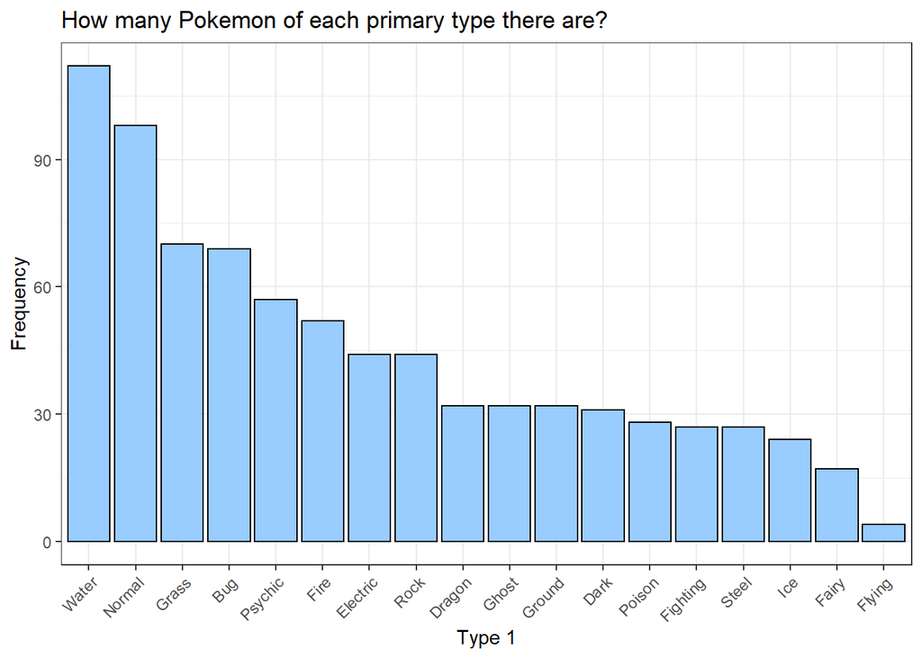

```r
ggplot(mydata, aes(x=fct_infreq(Type.1))) +
  geom_bar(fill="#99CCFF", colour="black") +
  labs(x="Type 1", y="Frequency",
       title="How many Pokemon of each primary type there are?") +
  theme_bw() +
  theme(axis.text.x=element_text(angle=45, hjust=1))
```

Next, I will select() columns of interest:

```r
pokemon_types <- select(
  mydata,
  Name,  # column names I want to keep
  Type.1,
  Type.2)

head(pokemon_types)
```

```
##                    Name Type.1 Type.2
## 1             Bulbasaur  Grass Poison
## 2               Ivysaur  Grass Poison
## 3              Venusaur  Grass Poison
## 4 VenusaurMega Venusaur  Grass Poison
## 5            Charmander   Fire
## 6            Charmeleon   Fire
```

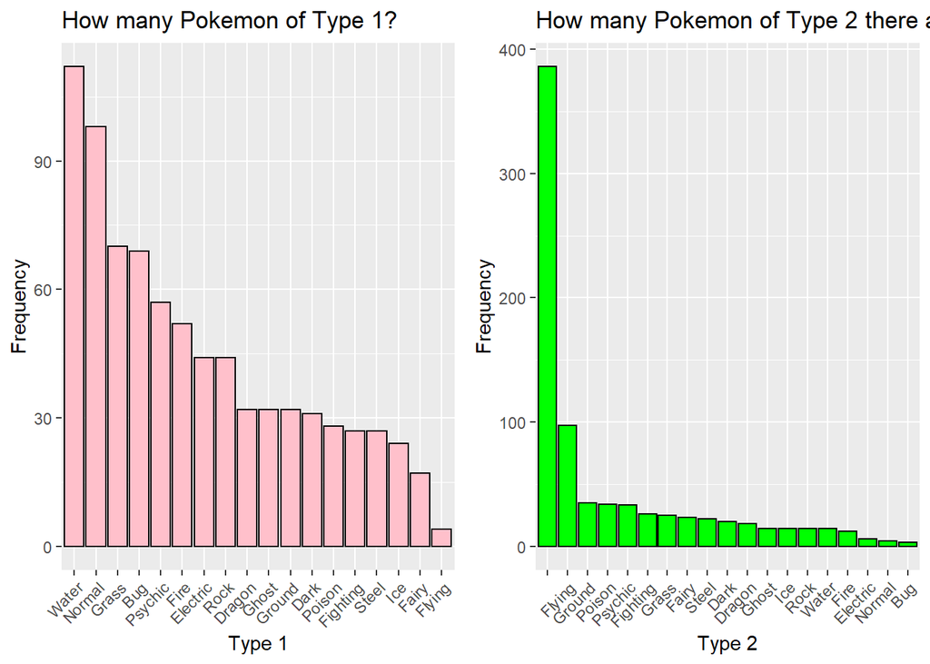

```r
ggplot(pokemon_types, aes(x=fct_infreq(Type.1))) + # Oreder by the frequency
theme(axis.text.x = element_text(angle = 45, hjust = 1)) + # Rotates the X labels
labs(x="Type 1", y="Frequency",
     title="How many Pokemon of Type 1?") +
geom_bar(fill="pink", colour="black") -> p1

ggplot(pokemon_types, aes(x=fct_infreq(Type.2))) + # Oreder by the frequency
theme(axis.text.x = element_text(angle = 45, hjust = 1)) +  # Rotates the X labels
labs(x="Type 2", y="Frequency",
     title="How many Pokemon of Type 2 there are?") +
geom_bar(fill="green", colour="black", beside = TRUE) -> p2

grid.arrange(p1, p2, ncol = 2)
```

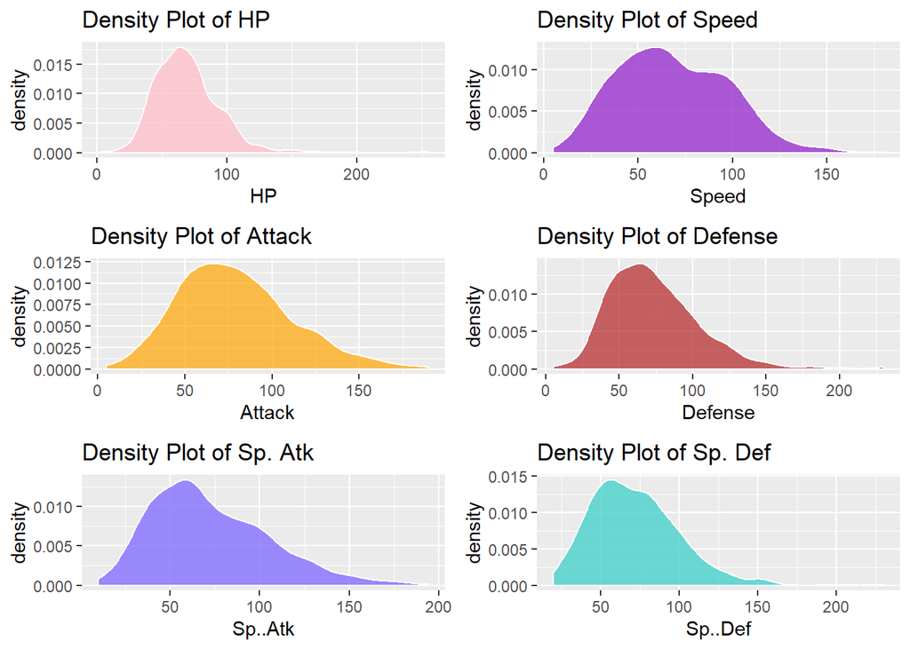

```r
density_hp <- ggplot(data=mydata, aes(HP)) + geom_density(col="white",fill="pink", alpha=0.8) + ggtitle("Density Plot of HP")
density_speed <- ggplot(data=mydata, aes(Speed)) + geom_density(col="white", fill="darkorchid", alpha=0.8) + ggtitle("Density Plot of Speed")
density_attack <- ggplot(data=mydata, aes(Attack)) + geom_density(col="white", fill="orange", alpha=0.7) + ggtitle("Density Plot of Attack ")
density_defense <- ggplot(data=mydata, aes(Defense)) + geom_density(col="white", fill="firebrick", alpha=0.7) + ggtitle("Density Plot of Defense ")
density_SpAtk <- ggplot(data=mydata, aes(Sp..Atk)) + geom_density(col="white", fill="slateblue1", alpha=0.8) + ggtitle("Density Plot of Sp. Atk ")
density_SpDef <- ggplot(data=mydata, aes(Sp..Def)) + geom_density(col="white", fill="mediumturquoise", alpha=0.8) + ggtitle("Density Plot of Sp. Def")

grid.arrange(density_hp, density_speed, density_attack, density_defense, density_SpAtk, density_SpDef, ncol=2)
```

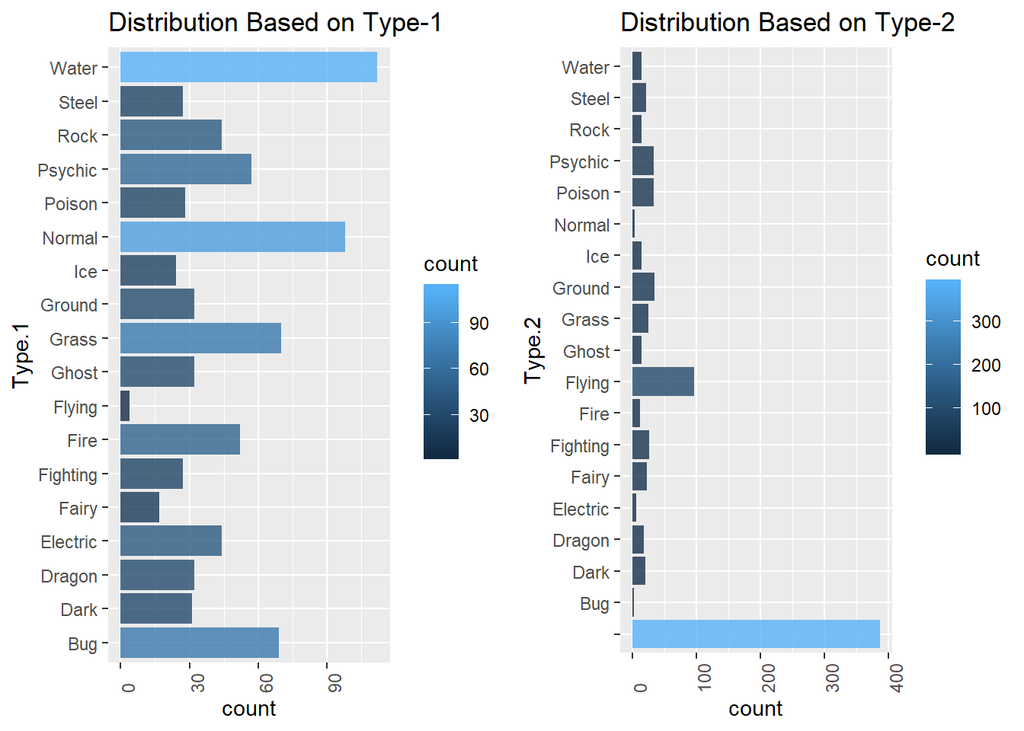

```r
type_1_poke <- ggplot(data=mydata, aes(Type.1)) + geom_bar(aes(fill=..count..), alpha=0.8) + theme(axis.text.x = element_text(angle = 90, hjust = 0)) + ggtitle("Distribution Based on Type-1") + coord_flip()
type_2_poke <- ggplot(data=mydata, aes(Type.2)) + geom_bar(aes(fill=..count..), alpha=0.8) + theme(axis.text.x = element_text(angle = 90, hjust = 0)) + ggtitle("Distribution Based on Type-2") + coord_flip()
grid.arrange(type_1_poke, type_2_poke, ncol=2)
```

As we can see from the plots above, Flying as Type 2 is the most frequented type, not like as Type 1 which its frequency is very low. If we will look at the Bug type, it has the most least apearances as type 2, but as type 1 its above the average.

```r
#lets create small data frame which include only this two features
new_data<- select(mydata, Generation, Total)
head(new_data)
```

```
##   Generation Total
## 1          1   318
## 2          1   405
## 3          1   525
## 4          1   625
## 5          1   309
## 6          1   405
```

```r
cor(new_data)
```

```
##            Generation      Total
## Generation 1.00000000 0.04838402
## Total      0.04838402 1.00000000
```

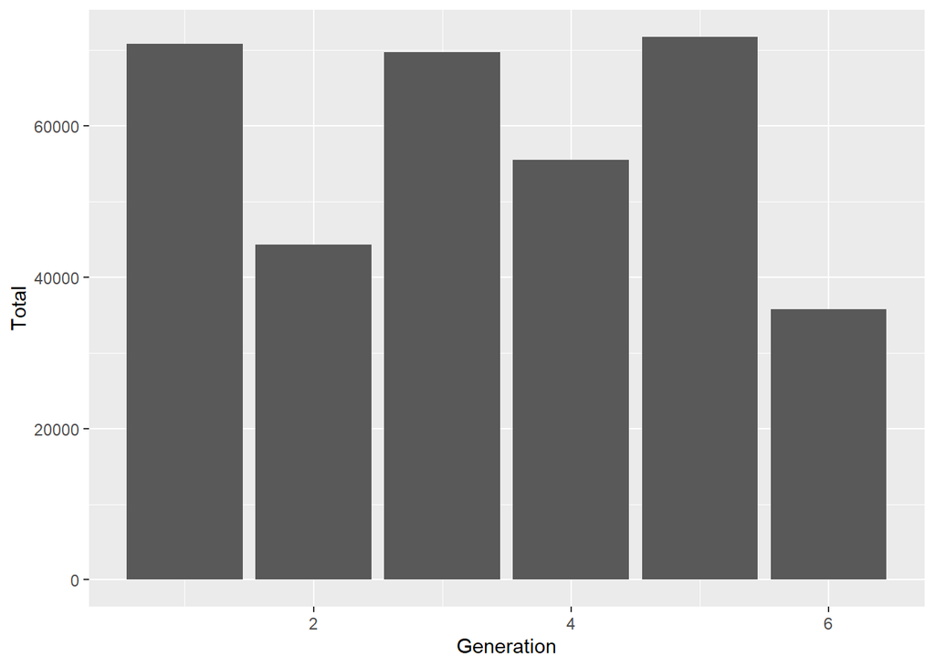

```r
p <- ggplot(new_data, aes(Generation, Total))
p + geom_bar(stat="identity")
```

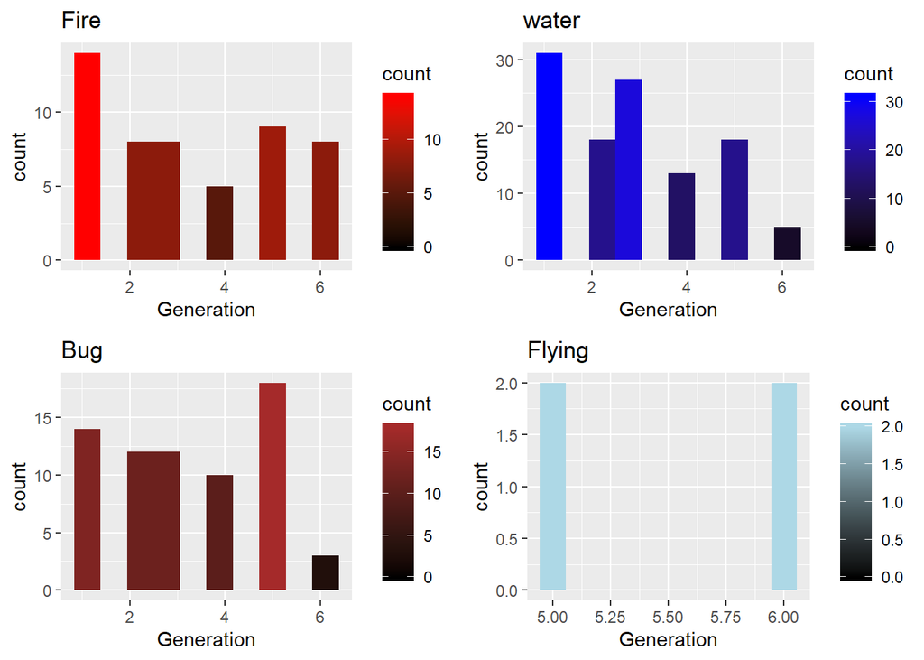

```r
water = filter(mydata, Type.1 == "Water")
fire = filter(mydata, Type.1 == "Fire")
bug = filter(mydata, Type.1 == "Bug")
flying = filter(mydata, Type.1 == "Flying")

gen_water <- ggplot(water, aes(Generation)) + geom_histogram(aes(fill = ..count..), bins = 10) + ggtitle("water") + scale_fill_gradient(low="black", high="blue")
gen_fire <- ggplot(fire, aes(Generation)) + geom_histogram(aes(fill = ..count..), bins = 10) + ggtitle("Fire") + scale_fill_gradient(low="black", high="red")
gen_bug <- ggplot(bug, aes(Generation)) + geom_histogram(aes(fill = ..count..), bins = 10) + ggtitle("Bug") + scale_fill_gradient(low="black", high="brown")
gen_flying <- ggplot(flying, aes(Generation)) + geom_histogram(aes(fill = ..count..), bins = 10) + ggtitle("Flying") + scale_fill_gradient(low="black", high="lightblue")

grid.arrange(gen_fire, gen_water, gen_bug, gen_flying, ncol=2)
```

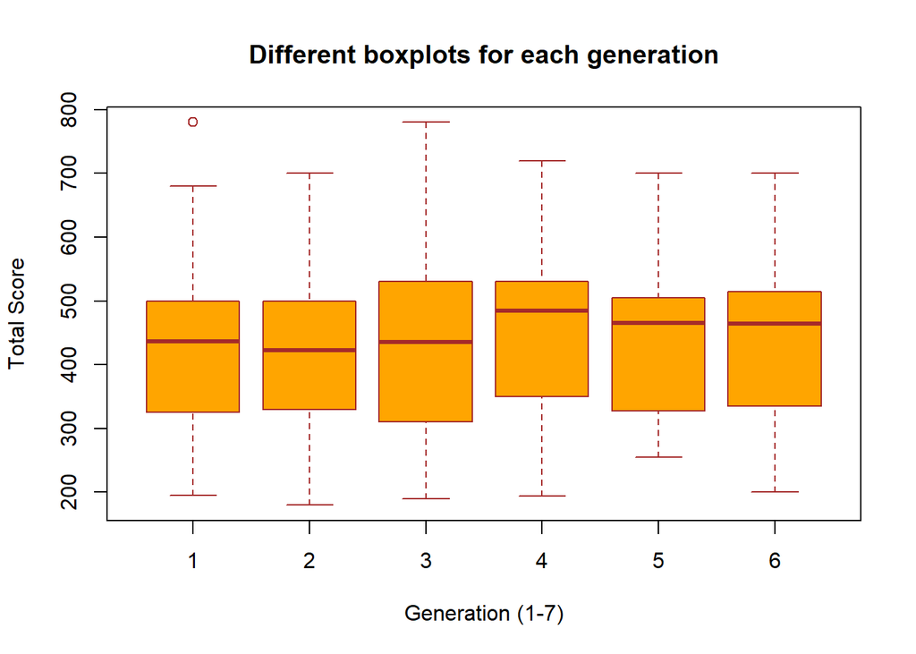

```r
boxplot(Total~Generation,
data=mydata,
main="Different boxplots for each generation",
xlab="Generation (1-7)",
ylab="Total Score",
col="orange",
border="brown")
```

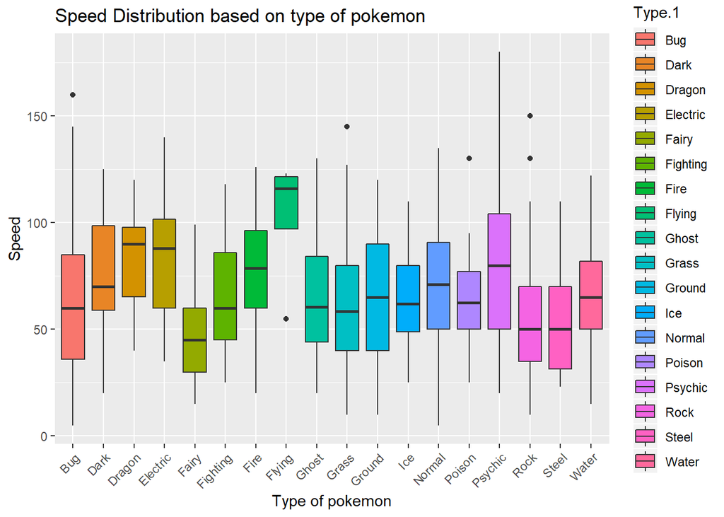

```r
ggplot(mydata) +
  geom_boxplot(aes(Type.1, Speed, fill = Type.1)) +
  xlab("Type of pokemon") +
  ylab("Speed") +
  theme(axis.text.x = element_text(angle = 45, hjust = 1)) +
  ggtitle("Speed Distribution based on type of pokemon")
```

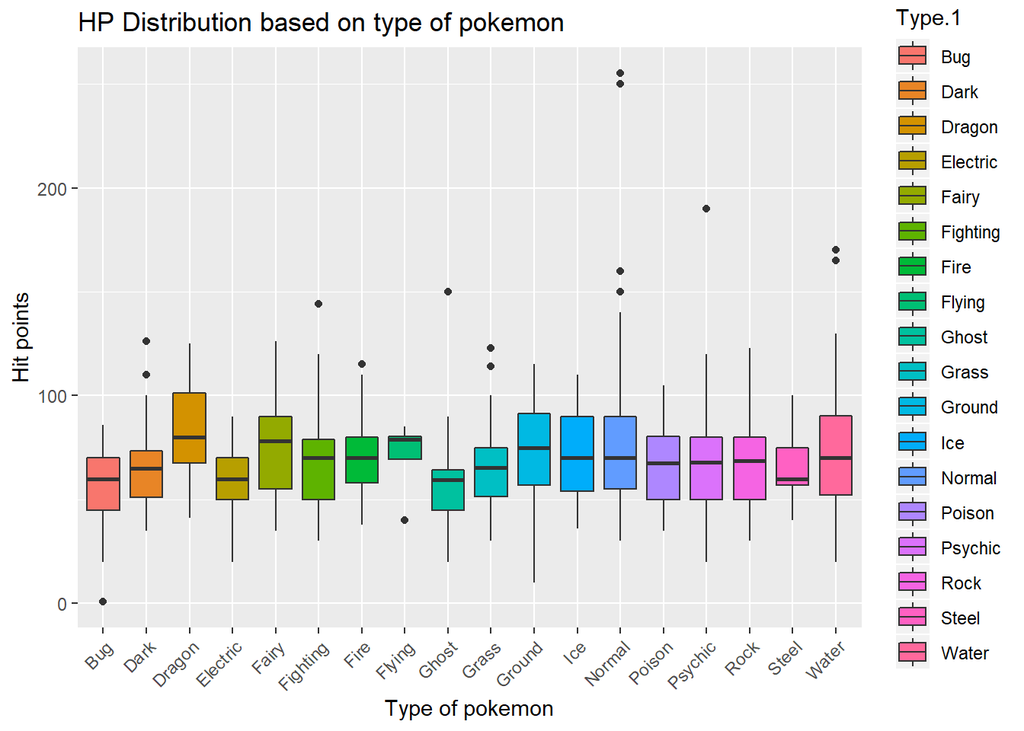

```r
ggplot(mydata) +
  geom_boxplot(aes(Type.1, HP, fill = Type.1)) +
  xlab("Type of pokemon") +
  ylab("Hit points") +
  theme(axis.text.x = element_text(angle = 45, hjust = 1)) +
  ggtitle("HP Distribution based on type of pokemon")
```

```r
# creating filtered data which contain Grass and Fire Types of Pokemons
Grass_Fire_data <- mydata %>% filter(Type.1 %in%
                                     c("Grass", "Fire"))

# Group by the types with their mean score:
Grass_Fire_data <- Grass_Fire_data %>% group_by(Type.1) %>% summarise(mean_score=mean(Total))
Grass_Fire_data
```

```
## # A tibble: 2 x 2
##   Type.1 mean_score
##   <fct>       <dbl>
## 1 Fire         458.
## 2 Grass        421.
```

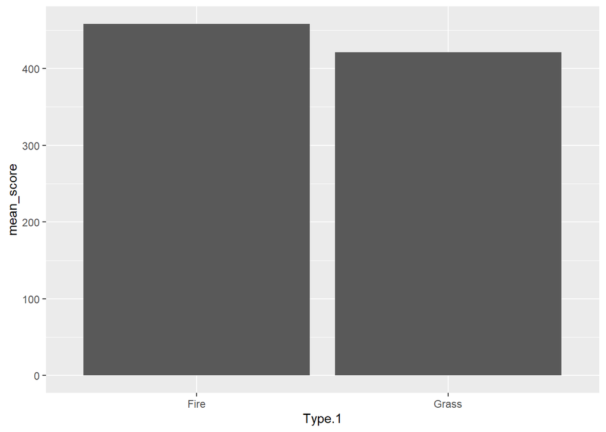

```r
# Plot this data.
p2 <- ggplot(Grass_Fire_data, aes(Type.1, mean_score))
p2 + geom_bar(stat="identity")
```

Linear regression allows us to model the relationship between two or more variables, utilizing some basic assumptions such as linearity, and normality. We will use this to describe and indicate statistically significant relationships.

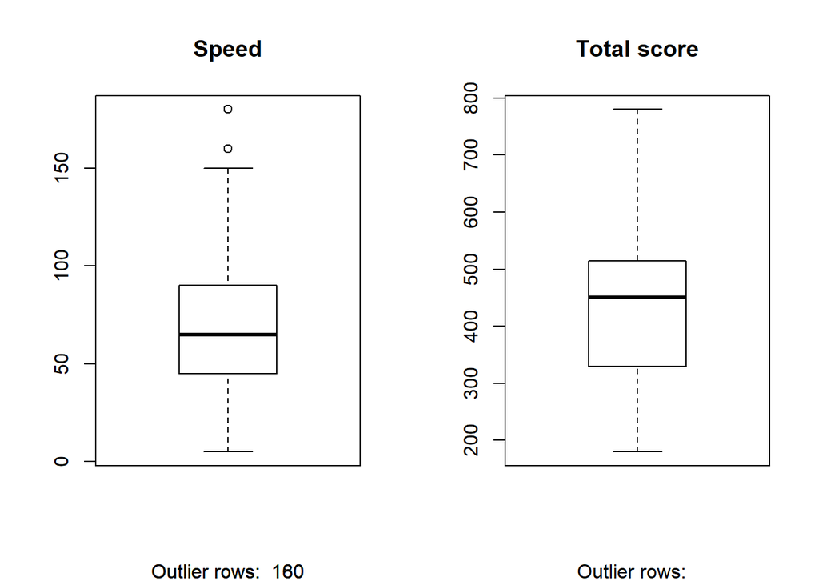

```r
par(mfrow=c(1, 2))  # divide graph area in 2 columns
boxplot(mydata$Speed, main="Speed", sub=paste("Outlier rows: ", boxplot.stats(mydata$Speed)$out))  # box plot for 'speed'
boxplot(mydata$Total, main="Total score", sub=paste("Outlier rows: ", boxplot.stats(mydata$Total)$out))  # box plot for 'total'
```

We can see that there are two samples which detected as Outliers

[figure not shown]

```r
speed_attack_legendary <- ggplot(na.omit(mydata), aes(Attack, Speed)) + geom_point(aes(color=Legendary)) + geom_label_repel(data=subset(mydata, (Attack > 170 | Attack < 50 & Speed >150 | Speed < 50) & Legendary == 1 | Speed > 145), aes(label=Name), box.padding = 0.35, point.padding = 0.5, segment.color = 'grey50') + geom_smooth(method = "lm")

hp_attack_legendary <- ggplot(na.omit(mydata), aes(Attack, HP)) + geom_point(aes(color=Legendary)) + geom_label_repel(data=subset(mydata, ((Attack > 170 | HP > 190 | Attack < 50) & Legendary == 1) | HP >160), aes(label=Name), box.padding = 0.35, point.padding = 0.5, segment.color = 'grey50')  + geom_smooth(method = "lm")

grid.arrange(speed_attack_legendary, hp_attack_legendary, ncol = 2)
```

There exists a weak positive relationship between the Speed and the Attack attributes but a stronger positive linear relationship between HP and the Attack attribute. The legendary Pokemons are labeled on the scatter plot. Most of the legendary pokemons have higher speed and HP than other.

[figure not shown]

```r
hp_defense_legendary <- ggplot(na.omit(mydata), aes(Defense, HP)) + geom_point(aes(color=Legendary)) + geom_label_repel(data=subset(mydata, (Defense > 150 | Defense < 50 | HP > 150) & Legendary == 1 | HP > 200), aes(label=Name), box.padding = 0.35, point.padding = 0.5, segment.color = 'grey50') + geom_smooth(method = "lm")

speed_defense_legendary <- ggplot(na.omit(mydata), aes(Defense, Speed)) + geom_point(aes(color=Legendary)) + geom_label_repel(data=subset(mydata, (Defense > 130 | Defense < 50| Speed > 140 | Speed < 50) & Legendary == 1), aes(label=Name), box.padding = 0.35, point.padding = 0.5, segment.color = 'grey50') + geom_smooth(method = "lm")

grid.arrange(speed_defense_legendary, hp_defense_legendary, ncol = 2)
```

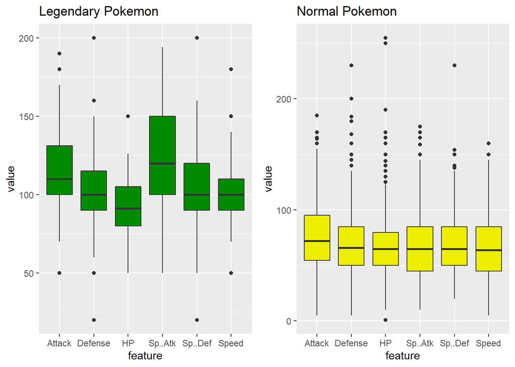

```r
box_plot_attr <- select(mydata, Type.1, Legendary, HP, Defense, Attack, Sp..Atk, Sp..Def, Speed)
box_plot_attr_leg <- filter(box_plot_attr, Legendary == 1)
box_plot_attr_nor <- filter(box_plot_attr, Legendary == 0)
box_plot_attr_leg_long <- gather(box_plot_attr_leg, feature, value, -c(Type.1, Legendary))
box_plot_attr_nor_long <- gather(box_plot_attr_nor, feature, value, -c(Type.1, Legendary))
bp_leg <- ggplot(data = box_plot_attr_leg_long, aes(feature, value)) + geom_boxplot(fill="green4") + ggtitle("Legendary Pokemon")
bp_nor <- ggplot(data = box_plot_attr_nor_long, aes(feature, value)) + geom_boxplot(fill = "yellow2") + ggtitle("Normal Pokemon")
grid.arrange(bp_leg, bp_nor,ncol=2)
```

As we can see in the Box plots above, we detect some outliers in almost every feature. The values of the normal pokemon are pretty much at the same value (around 75) between the features. The average value of the legendaries is higher (around 110), and the Sp..atk has got the highest value comparing to others features.

```r
#detects and removing Outliers:
outliers <- boxplot(mydata$Speed, plot=FALSE)$out
outliers_HP <- boxplot(mydata$HP, plot=FALSE)$out

# Check the results
print(outliers)
```

```
## [1] 160 180
```

```r
print(outliers_HP)
```

```
##  [1] 140 250 130 130 160 190 255 150   1 144 130 170 150 135 150 150 165
## [18] 126 126
```

```r
myNewData<- mydata
myNewData$Legendary  <- as.numeric(myNewData$Legendary == "True")
head(myNewData)
```

```
##   X.                  Name Type.1 Type.2 Total HP Attack Defense Sp..Atk
## 1  1             Bulbasaur  Grass Poison   318 45     49      49      65
## 2  2               Ivysaur  Grass Poison   405 60     62      63      80
## 3  3              Venusaur  Grass Poison   525 80     82      83     100
## 4  3 VenusaurMega Venusaur  Grass Poison   625 80    100     123     122
## 5  4            Charmander   Fire          309 39     52      43      60
## 6  5            Charmeleon   Fire          405 58     64      58      80
##   Sp..Def Speed Generation Legendary
## 1      65    45          1         0
## 2      80    60          1         0
## 3     100    80          1         0
## 4     120    80          1         0
## 5      50    65          1         0
## 6      65    80          1         0
```

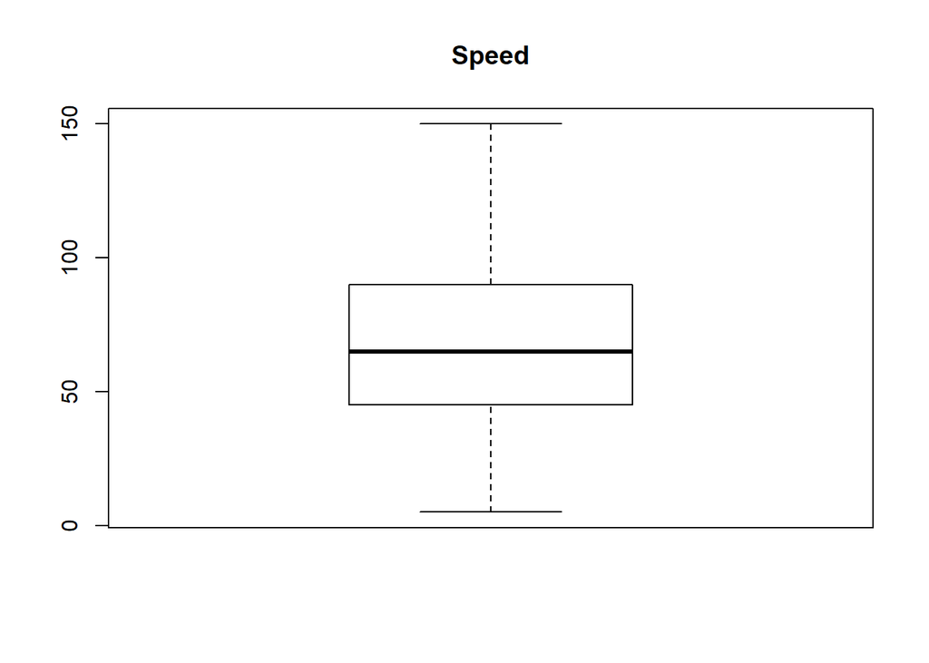

```r
myNewData <- mydata[-which(mydata$Speed %in% outliers),]
myNewData <- myNewData[-which(myNewData$HP %in% outliers_HP),]
boxplot(myNewData$Speed, main="Speed")
```

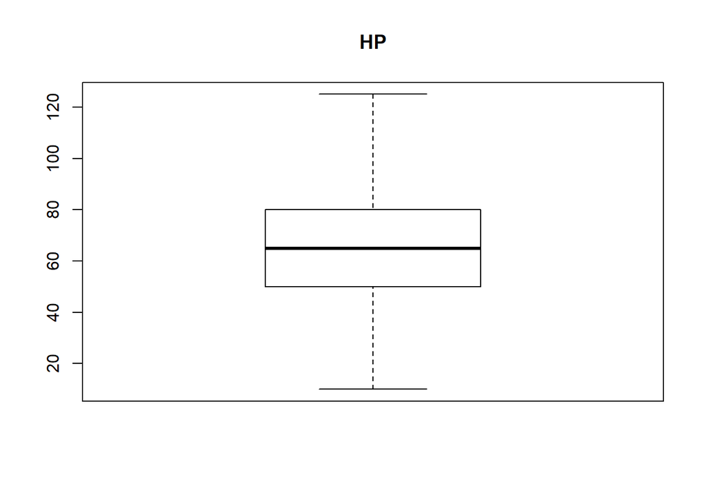

```r
boxplot(myNewData$HP, main="HP")
```

```r
SomeData<-myNewData %>%
  filter(Type.1 %in% c("Fire", "Water", "Bug", "Flying"))

SomeData <- subset(SomeData, select = -c(X., Name, Type.2))
head(SomeData)
```

```
##   Type.1 Total HP Attack Defense Sp..Atk Sp..Def Speed Generation
## 1   Fire   309 39     52      43      60      50    65          1
## 2   Fire   405 58     64      58      80      65    80          1
## 3   Fire   534 78     84      78     109      85   100          1
## 4   Fire   634 78    130     111     130      85   100          1
## 5   Fire   634 78    104      78     159     115   100          1
## 6  Water   314 44     48      65      50      64    43          1
##   Legendary
## 1         0
## 2         0
## 3         0
## 4         0
## 5         0
## 6         0
```

```r
# install.packages('mltools')
# install.packages('dummies')

myNewDataHot<- dummy.data.frame(SomeData, name = c("Type.1"), sep="_")
head(myNewDataHot)
```

```
##   Type.1_Bug Type.1_Fire Type.1_Flying Type.1_Water Total HP Attack
## 1          0           1             0            0   309 39     52
## 2          0           1             0            0   405 58     64
## 3          0           1             0            0   534 78     84
## 4          0           1             0            0   634 78    130
## 5          0           1             0            0   634 78    104
## 6          0           0             0            1   314 44     48
##   Defense Sp..Atk Sp..Def Speed Generation Legendary
## 1      43      60      50    65          1         0
## 2      58      80      65    80          1         0
## 3      78     109      85   100          1         0
## 4     111     130      85   100          1         0
## 5      78     159     115   100          1         0
## 6      65      50      64    43          1         0
```

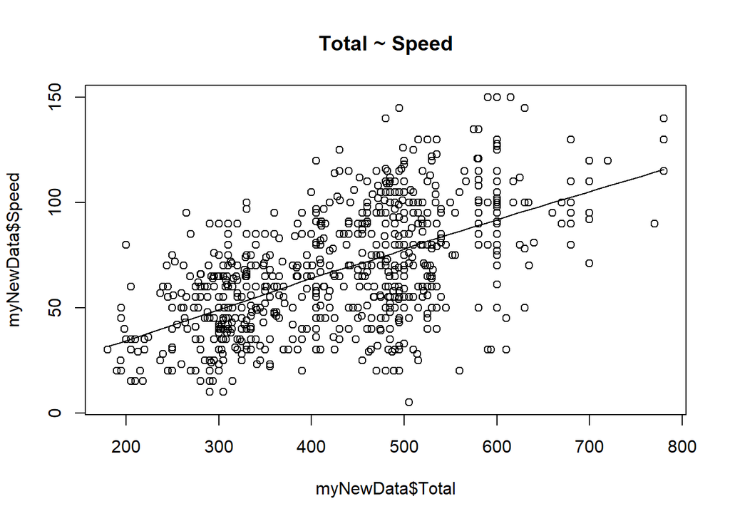

```r
scatter.smooth(x=myNewData$Total, y=myNewData$Speed, main="Total ~ Speed")  # scatterplot
```

# The Linear Regression Model

```r
linearMod <- lm(Total ~ Speed, data=myNewData)  # build linear regression model on full data
print(linearMod)
```

```
##
## Call:
## lm(formula = Total ~ Speed, data = myNewData)
##
## Coefficients:
## (Intercept)        Speed
##     268.195        2.416
```

Lets see how to relation between the speed and the Total score which depends on the speed score looks like:

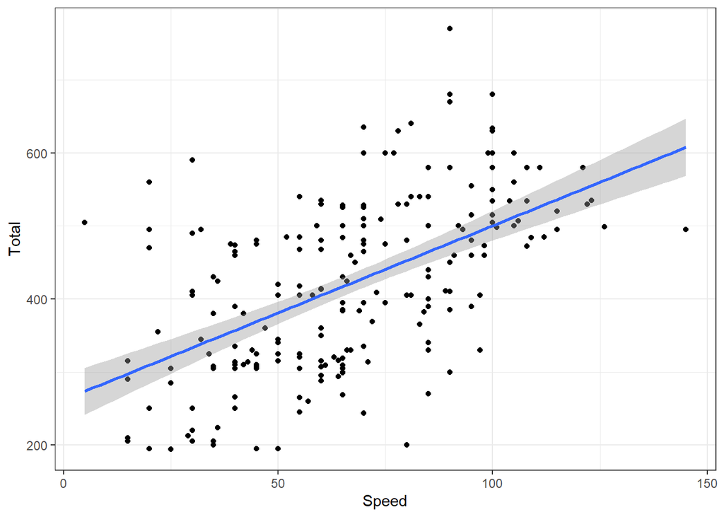

```r
ggplot(myNewDataHot, aes(x = Speed, y = Total)) +
 geom_point() + theme_bw() +
 stat_smooth(method = "lm") + xlab("Speed")
```

The samples are too scattered, let’s try to apply log on the y axis and see if it helps:

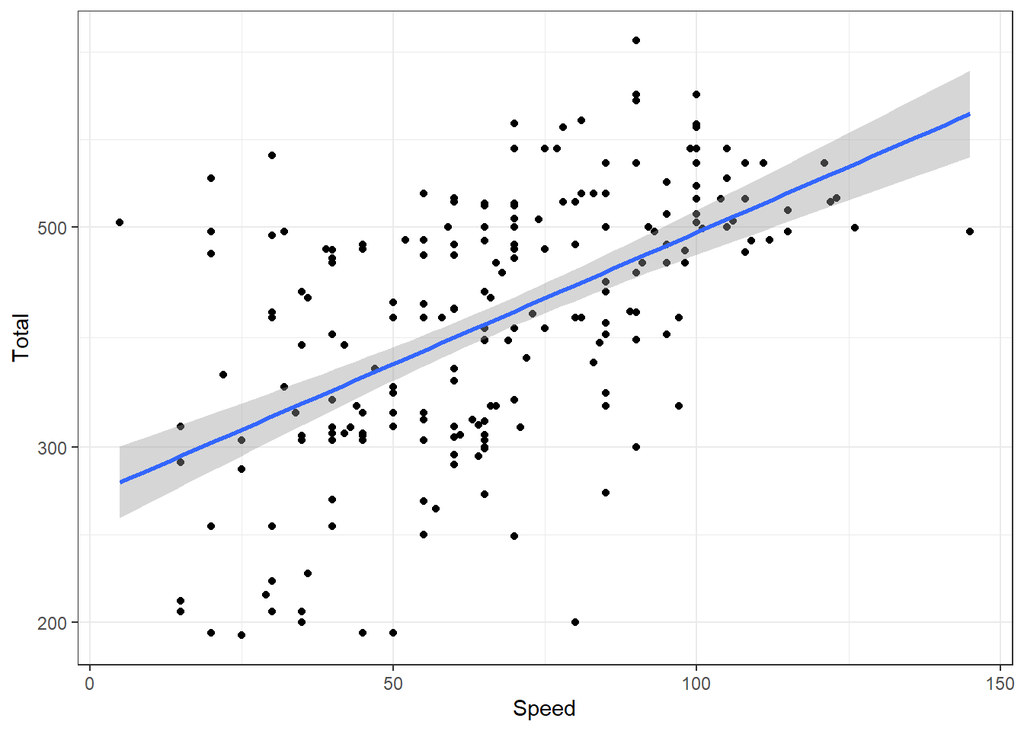

```r
ggplot(myNewDataHot, aes(x = Speed, y = Total)) +
 geom_point() + scale_y_log10() + theme_bw() +
 stat_smooth(method = "lm") + xlab("Speed")
```

```r
summary(linearMod)  # model summary
```

```
##
## Call:
## lm(formula = Total ~ Speed, data = myNewData)
##
## Residuals:
##     Min      1Q  Median      3Q     Max
## -261.49  -68.92  -11.92   69.58  284.35
##
## Coefficients:
##             Estimate Std. Error t value Pr(>|t|)
## (Intercept) 268.1949     8.9779   29.87   <2e-16 ***
## Speed         2.4162     0.1214   19.90   <2e-16 ***
## ---
## Signif. codes:  0 '***' 0.001 '**' 0.01 '*' 0.05 '.' 0.1 ' ' 1
##
## Residual standard error: 97.17 on 777 degrees of freedom
## Multiple R-squared:  0.3377, Adjusted R-squared:  0.3368
## F-statistic: 396.2 on 1 and 777 DF,  p-value: < 2.2e-16
```

The R-Squared is not very high, around 0.33 which means that only 33% of the variation in the dependent variable is explained by the independent variable. But the p-Value is very important because, We can consider a linear model to be statistically significant only when p-Value is less that the statistical significance level, which is 0.05. This is visually interpreted by the significance stars at the end of the row. The more the stars beside the variable’s p-Value, the more significant the variable. Here we can see that there is three stars which is the most significant.

Due to this results we can determine which there is a linear corrolotaion between Total and Speed.

```r
data_smaller <- select(
  myNewData,
  Total,  # column names I want to keep
  HP,)

head(data_smaller)
```

```
##   Total HP
## 1   318 45
## 2   405 60
## 3   525 80
## 4   625 80
## 5   309 39
## 6   405 58
```

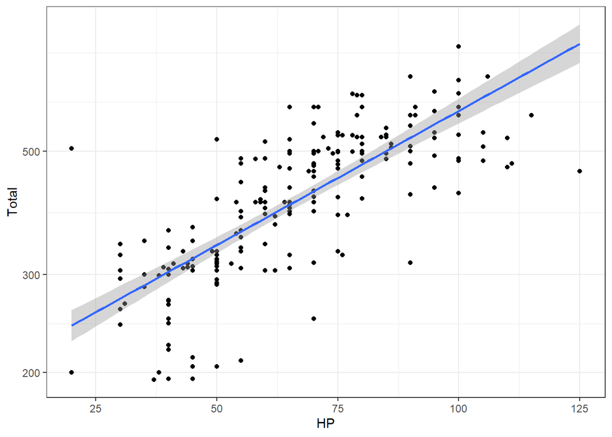

```r
ggplot(myNewDataHot, aes(x = HP, y = Total)) +
 geom_point() + scale_y_log10() + theme_bw() +
 stat_smooth(method = "lm") + xlab("HP")
```

```r
linearMod2 <- lm(Total ~ HP, data=myNewData)  # build linear regression model on full data
print(linearMod2)
```

```
##
## Call:
## lm(formula = Total ~ HP, data = myNewData)
##
## Coefficients:
## (Intercept)           HP
##     167.215        3.947
```

```r
summary(linearMod2)
```

```
##
## Call:
## lm(formula = Total ~ HP, data = myNewData)
##
## Residuals:
##     Min      1Q  Median      3Q     Max
## -351.08  -54.81   -3.48   52.36  335.45
##
## Coefficients:
##             Estimate Std. Error t value Pr(>|t|)
## (Intercept) 167.2147    10.2842   16.26   <2e-16 ***
## HP            3.9466     0.1458   27.07   <2e-16 ***
## ---
## Signif. codes:  0 '***' 0.001 '**' 0.01 '*' 0.05 '.' 0.1 ' ' 1
##
## Residual standard error: 85.66 on 777 degrees of freedom
## Multiple R-squared:  0.4853, Adjusted R-squared:  0.4847
## F-statistic: 732.7 on 1 and 777 DF,  p-value: < 2.2e-16
```

Here comparing to the previouse Linear Reggresion test, here can see that the R-squared is a little higher and we can see in the plot that the density of the samples is higher than in the Speed~Total plot. The relation between HP to Total is a bit stronger than the relation between Speed and Total.

# Noraml qq plot

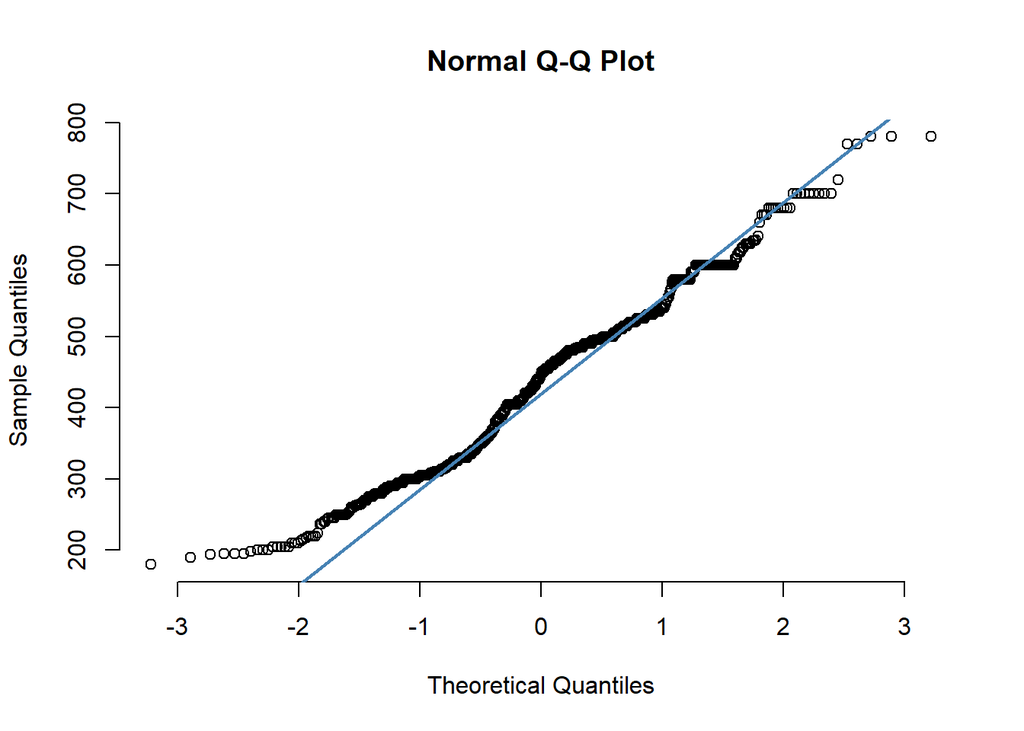

```r
# qq plot for the Total feature
qqnorm(myNewData$Total, pch = 1, frame = FALSE)
qqline(myNewData$Total, col = "steelblue", lwd = 2)
```

Quantile-quantile (Q-Q) plot is a graphical display to compare a data set to a particular probability distribution or to compare it to another data set. If the data are exactly normal, we expect the points to lie on a straight line. The data we have here are pretty close to lying on a line.

#Hypothesis test: Null Hypothesis: The average in HP of Bug Type Pokemon is equal to the HP of Flyig Type Pokemon. Alternative Hypothesis: The average in HP of Bug Type Pokemon is not equal to the HP of Flyig Type Pokemon.

```r
# creating filtered data which contain the Bug and Flying Types of Pokemons
Bug_Flying_data <- myNewData %>% filter(Type.1 %in%
                                     c("Bug", "Flying"))

# Group by the types with their mean score:
Bug_Flying_data2 <- Bug_Flying_data %>% group_by(Type.1) %>% summarise(mean_score=mean(Total))
Bug_Flying_data2
```

```
## # A tibble: 2 x 2
##   Type.1 mean_score
##   <fct>       <dbl>
## 1 Bug          380.
## 2 Flying       485
```

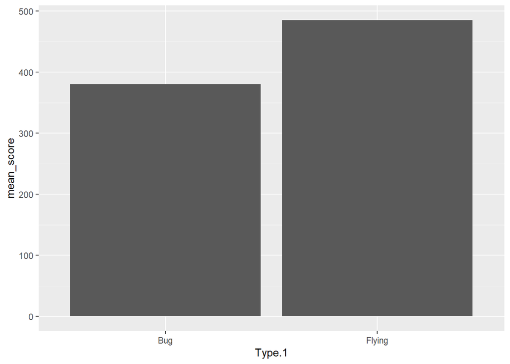

```r
# Plot this data.
p2 <- ggplot(Bug_Flying_data2, aes(Type.1, mean_score))
p2 + geom_bar(stat="identity")
```

Let’s do the Hypothesis test We use t-test to determine whether the means of two Types are equal to each other. The assumption for the test is that both groups are sampled from normal distributions with equal variances. The null hypothesis is that the two means are equal, and the alternative is that they are not equal.

To perform two-samples t-test comparing the means of two independent samples (x & y), the R function t.test() can be used as follow:

```r
# R function to compute unpaired two-samples t-test
t.test(x = myNewDataHot$HP[myNewDataHot$Type.1_Bug == "1"], y = myNewDataHot$HP[myNewDataHot$Type.1_Flying == "1"], alternative = "two.sided")
```

```
##
##  Welch Two Sample t-test
##
## data:  myNewDataHot$HP[myNewDataHot$Type.1_Bug == "1"] and myNewDataHot$HP[myNewDataHot$Type.1_Flying == "1"]
## t = -1.2459, df = 3.1923, p-value = 0.2964
## alternative hypothesis: true difference in means is not equal to 0
## 95 percent confidence interval:
##  -45.42678  19.24021
## sample estimates:
## mean of x mean of y
##  57.65672  70.75000
```

The p-value of t-test is p = 0.2964. It’s greater than the significance level alpha = 0.05. In conclusion,we failed to reject that there is no significant difference between the average HP score of the two Types of pokemons. We can also support this due to the confidence interval which results here.

# Conclusion:

In this project I gained experience writing code and implementing the course material while researching the Pokemon data set. Throuhout the data research various visualization methods were utilized in ways that facilitated knowledge of the data and raised questions and hypothesis that interest me, to eventually be answered using model and hypothesis test.